# Finding Your Center

## The Average in R : **mean()**

R provides an extremely strightforward way of calculating the mean of a set of numbers : *mean()*. Here is the example of the hights of six children.

```r
heights <- c(36,42,43,37,40,45)
```

Then *mean()* function will output the average of this data.

```r
mean(heights)
```

```
[1] 40.5
```

### conditing

For the discussion that follows, we use the same *Cars93* data frame that we use in last section. It’s the one that has data for a sample 93 cars from 1993. It’s in the MASS packege. So make sure to include the MASS packege in the library.

```r
library("MASS")
```

Now, suppose we are interesting in the average horsepower of the cars made in the USA. First we select those cars and put their horsepowers into a vector:

```r
Horsepower.USA <- Cars93$Horsepower[Cars93$Origin == "USA"]
```

The average horsepower is then

```r
mean(Horsepower.USA)
```

```
[1] 147.5208
```

How about the average for cars not made in the USA:

```r
Horsepower.NonUSA <- Cars93$Horsepower[Cars93$Origin == "non-USA"]
mean(Horsepower.NonUSA)
```

```
[1] 139.8889
```

### Eliminate $-sign forth *with()*

In the preceding R-code, the $-signs denote variables in the *Cars93* data frame. R provides a way out of using the name of the data frame each time we refer to one of its variable.

The function *with()* does this for other R functions. The first argumnet is the data source, and the second argument is the function to apply to a variable in that data source.

For example, to find the mean horsepower of USA cars in Cars93:

```r
with(Cars93, mean(Horsepower[Origin == "USA"]))
```

```
[1] 147.5208
```

What about multiple conditions, like the average horsepower of USA 4-Cylinder cars?

```r
with(Cars93,mean(Horsepower[Origin == "USA" & Cylinders == 4]))
```

```
[1] 104.0909
```

### Exploring the data

Now that we’ve examined the horsepower means of USA and non-USA cars, how about the overall distribution?

We are still using the *ggplot()* to create side-by-side histograms from the Cars93 frame so that we can compare them.

First, have to notice and have included the *ggplot()* package.

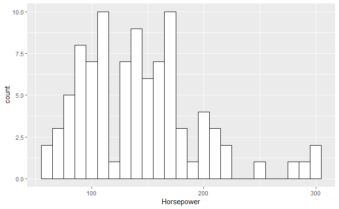

```r
library("ggplot2")
ggplot(Cars93,aes(x = Horsepower)) + geom_histogram(color = "black" , fill = "white",binwidth = 10)
```

The code so far creates an orignary histogram with *Horsepower* on the x-axis. How can we create that split the the data bese on the origin, like *USA* and *non-USA*? To do that, I add a ggplot capabiilty called *faceting*. Simply put, faceting splits the data according to a norminal variable – like *Origin*, which is either “USA” or “non-USA” A couple of faceting function are available. The one we use here is call *facet_wrap()*. To split the data according to *Origin*, it’s

```r
facet_wrap(~Origin)
```

Altogether,

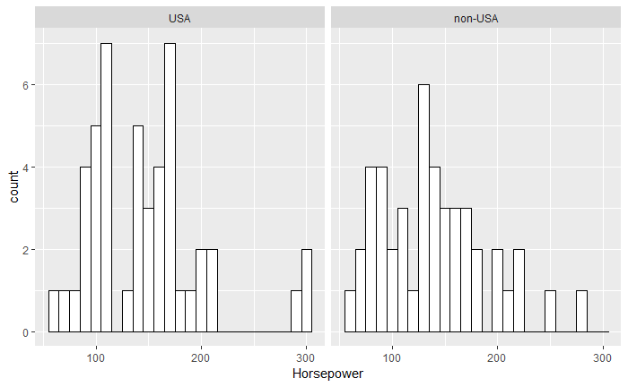

```r
ggplot(Cars93,aes(x = Horsepower)) + geom_histogram(color = "black" , fill = "white",binwidth = 10) + facet_wrap(~Origin)
```

### Outliers : The flaw of averages

An outliers is an extreme value in a data set. If the data is a sample and you’re trying to estimate the population mean, the outlier might bias the estimate.

statisticians deal with outliers by *trimming* the mean – eliminating extreme values at the low end and high end before calculating the sample maen. The amount of trim is a percentage, like the upper and lower 5 percent of the scores.

```r
mean(Horsepower.NonUSA,trim = .05)
```

```
[1] 137.4878
```

## The Median in R : median()

With larger data sets, you might encounter replication of scores. In any case, the median is still the middle value. For example, here are the horsepowers for 4-cylinder cars in *Cars93* :

```r
Horsepower.Four <- with(Cars93, Horsepower[Cylinders == 4])
sort(Horsepower.Four)
```

```
 [1]  63  74  81  81  82  82  85  90  90  92  92  92  92  92  93  96 100 100 100 102 103 105 110 110 110 110 110 110 110 114 115 124 127
[34] 128 130 130 130 134 135 138 140 140 140 141 150 155 160 164 208
```

```r
median(Horsepower.Four)
```

```
[1] 110
```

## The Mode in R

Base R does not provide a function for finding the mode. It does have a function called *mode()*, but it’s for something much different. Instead, you need a package called *modeest* in your library. (On the Packages tab, select Install, and then in the Install dialog box, type **modeest** in the Packages box and click Install. Then check its check box when it appear on the Packages tab.)

```r
library("modeest")
```

[output not shown]

```r
scores <- c(1,2,2,2,3,4,4,4,5,6)
mfv(scores)
```

[output not shown]

## Deviating from the Average

### Measuring variation

Suppose we are measuring the heights of group of children and we find that their height (in inches) are

48, 48 , 48, 48, 48, and 48

Then we measure another group and find that their heights are

50,47,52,46, and 45

In fact, the mean of each group are the same. Just looking at the numbers tells you the two groups of heights are different: The heights in the first group are all the same, whereeas the heights in the second vary quite a bit.

#### Averaging square derivations : Variance and how to calculate it

One way to know the dissimilarity between the two groups is to examine the deviations in each one. Think of a “deviation” as the difference between a score and the mean of all the scores in a group.